# MY472 Final Exam Part B: Descriptive Analysis

The goal of this second part of the assignment is to analyze the datasets you just created in order to answer a set of descriptive questions. Your answer to the questions will offer important context towards the overall research question: **Why is there so much negativity on Facebook comments about politics?**

For each item below, you should write code with any statistical or graphical analysis that you consider appropriate, and then answer the question.

```r
library("ggplot2")
library("lubridate")
library("dplyr")
library("purrr")
library("DBI")
library("ggrepel")
```

```r
# Open connection
fbdb <- dbConnect(RSQLite::SQLite(), "fbdata.sqlite")

# Check that tables are in database
dbListTables(fbdb)
```

```
## [1] "comments"      "congress_list" "everypol"      "posts"
```

1. First of all, how much negativity is there on the comments of pages by U.S. legislators? In other words, what proportion of comments are negative?
- *The proportion of all comments that are negative is 49.87%.*

```r
df_prop_neg <- dbGetQuery(fbdb,
           "SELECT AVG(CASE WHEN sent_name == 'negative' THEN 1 ELSE 0 END)*100 as pct_neg
           FROM comments")

prop_neg <- round(df_prop_neg[1,1], 2)
```

```r
# Where variance = E(X^2) – m^2, find variance
var_sent <- dbGetQuery(fbdb,
          "SELECT AVG(sent_index) AS avg_sent,
          AVG(sent_index*sent_index) - AVG(sent_index)*AVG(sent_index) AS var_sent,
          SQRT(AVG(sent_index*sent_index) - AVG(sent_index)*AVG(sent_index)) AS stdev_sent
          FROM comments")

# Legislator with highest proportion of negative comments
df_prop_neg <- dbGetQuery(fbdb,
           "SELECT filename, AVG(CASE WHEN sent_name == 'negative' THEN 1 ELSE 0 END)*100 as prop_neg
           FROM comments
           GROUP BY filename
           ORDER BY prop_neg")

# Order df and find largest and smallest proportion of neg comments
df_prop_neg[order(df_prop_neg, decreasing = TRUE),]
```

[output not shown]

[output cut: 846 more lines]

[output not shown]

```r
lowest_neg <- df_prop_neg[1,] # Largest proportion of negative comments
top_neg <- df_prop_neg[nrow(df_prop_neg),] # Lowest proportion of negative comments
```

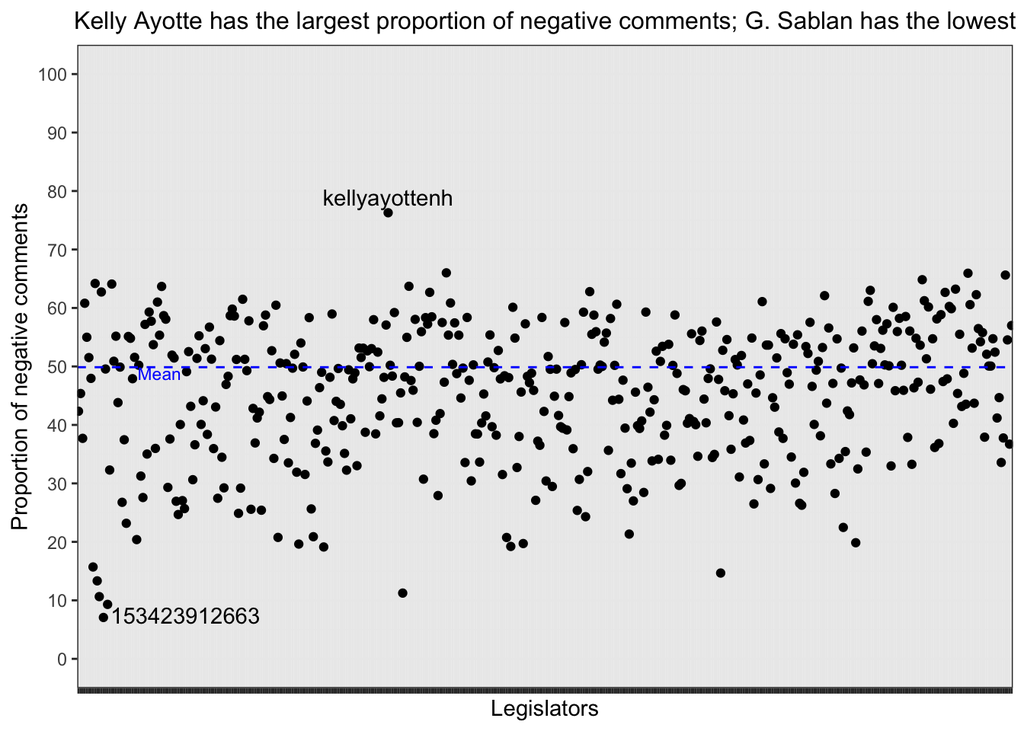

```r
ggplot() +
  geom_point(data = df_prop_neg, aes(x = filename, y = prop_neg)) +
  geom_hline(aes(yintercept = mean(prop_neg)), linetype = "dashed",
             color = "blue") +
  geom_text(data = data.frame(x = 40, y = mean(prop_neg)), aes(x, y),
            color = "blue",
            label = "Mean",
            vjust = 1,
            size = 3) +
  scale_y_continuous(breaks = seq(0, 100, 10), limits = c(0, 100)) +
  ggtitle("Kelly Ayotte has the largest proportion of negative comments; G. Sablan has the lowest") +
  xlab("Legislators") +
  ylab("Proportion of negative comments") +
  geom_text_repel(data = subset(df_prop_neg, prop_neg > 70 | prop_neg < 8),
            aes(x = filename, y = prop_neg, label = filename,
                vjust = 1, hjust = 0.5)) +
  theme_bw() +
  theme(
    plot.title = element_text(size = 12, hjust = 0.5),
    plot.subtitle = element_text(hjust = 0.5),
    axis.text.x = element_blank(),
    axis.line.x.bottom = element_blank()
  )
```

3. How did negativity evolve over time during the period of analysis? Do you identify any particular days or periods during which negativity spiked? Can you explain why?
- *Average sentiment over the period was 1.78 (where 1 is negative and 2 is neutral) – this means that comments were on average, just slightly more negative that neutral.*
- *Average sentiment stayed slightly below neutral (i.e. slightly more negative than neutral) for the entire period under observation, thought it dipped notably during the last observed month - February 2018. This could be due to events that occurred in early 2018, among which was the Stoneman Douglas shooting in Florida and a shooting in Kentucky. During that time, people were upset by school shooting and there was a big push on social media to criticize legislators who were not “tough” on arms regulation.*
- *Though average comment sentiment had started to cluster around the mean from 2015 on, there is a noticable increase in variance in the average sentiment in early 2017 which grew as the year progressed. This could be due to the beginning of Donald Trump’s presidency and the beginning of the Comey drama in U.S. politics (with FBI director James Comey having been fired on May 9th).*

```r
# Create table to determine average sentiment index over time (where 1 is negative, 2 is neutral, 3 is positive)
negativity_timeseries <- dbGetQuery(fbdb,
                                   "SELECT created_time, AVG(sent_index) as avg_sent
                                   FROM comments
                                   GROUP BY created_time
                                   ORDER BY created_time")

# Convert dates to date type
negativity_timeseries$created_time <- as.Date(negativity_timeseries$created_time) # to be used for day-to-day analysis

# Find monthly average
negativity_bymonth <- negativity_timeseries %>%
  group_by(month(created_time), year(created_time)) %>%
  purrr::set_names(c("created_time", "avg_sent", "month_m", "year_y"))

# Set type as numeric to facilitate data frame construction
negativity_bymonth$month_m <- as.numeric(negativity_bymonth$month_m)

# Modify date
negativity_bymonth$month_m <- with(negativity_bymonth, ifelse(month_m < 10, paste(0, month_m, sep = ""), month_m))
negativity_bymonth$final_date <- paste(negativity_bymonth$month_m, 01, negativity_bymonth$year_y, sep = "-")
negativity_bymonth$final_date <- as.Date(negativity_bymonth$final_date, tryFormats = c("%m-%d-%Y"))

# Calculate monthly averages
negativity_bymonth <- negativity_bymonth %>%
  group_by(final_date) %>%
  summarise(monthly_avg = mean(avg_sent))
```